# Project 1 Analysis on UMD Data

Wan Zhang 730341932

9/24/2019

This project draws analysis on the data set about support to the homeless provided by UMD. The purpose of this project:

- Figure out the trends of the services over years and distribution by month.
- Research the changes in the number of clients and cases of services over years.
- Predict the demand in 2019 if it linearly increases.

Firstly we observe the total summary on the data set.

```r
summary(df)
```

```
##      Date           Client File Number Client File Merge
##  Length:79838       Min.   :    1      Min.   :    0
##  Class :character   1st Qu.: 3199      1st Qu.:    0
##  Mode  :character   Median : 6969      Median :    0
##                     Mean   : 7290      Mean   : 4560
##                     3rd Qu.:11174      3rd Qu.:    0
##                     Max.   :16792      Max.   :70108
##                                        NA's   :37
##  Bus Tickets (Number of) Notes of Service   Food Provided for
##  Min.   : 0.00           Length:79838       Min.   :   0.000
##  1st Qu.: 0.00           Class :character   1st Qu.:   1.000
##  Median : 1.00           Mode  :character   Median :   2.000
##  Mean   : 1.35                              Mean   :   2.739
##  3rd Qu.: 2.00                              3rd Qu.:   4.000
##  Max.   :10.00                              Max.   :1151.000
##  NA's   :79580                              NA's   :22702
##   Food Pounds       Clothing Items      Diapers         School Kits
##  Min.   :     0.0   Min.   :  0.00   Min.   :   0.00   Min.   : 0.00
##  1st Qu.:     0.0   1st Qu.:  4.00   1st Qu.:   1.00   1st Qu.: 0.00
##  Median :    15.0   Median :  7.00   Median :  12.00   Median : 0.00
##  Mean   :    25.4   Mean   :  8.49   Mean   :  15.41   Mean   : 1.45
##  3rd Qu.:    25.0   3rd Qu.: 11.00   3rd Qu.:  12.00   3rd Qu.: 0.00
##  Max.   :450121.0   Max.   :247.00   Max.   :5303.00   Max.   :25.00
##  NA's   :12521      NA's   :10933    NA's   :78803     NA's   :79656
##   Hygiene Kits    Referrals         Financial Support Type of Bill Paid
##  Min.   :0.00    Length:79838       Min.   :  0.000   Length:79838
##  1st Qu.:1.00    Class :character   1st Qu.:  0.000   Class :character
##  Median :1.00    Mode  :character   Median :  0.000   Mode  :character
##  Mean   :0.98                       Mean   :  0.432
##  3rd Qu.:1.00                       3rd Qu.:  0.000
##  Max.   :8.00                       Max.   :450.000
##  NA's   :76650                      NA's   :3356
##  Payer of Support    Field1         Field2         Field3
##  Length:79838       Mode:logical   Mode:logical   Mode:logical
##  Class :character   NA's:79838     NA's:79838     TRUE:1
##  Mode  :character                                 NA's:79837
##
##
##
##
```

There are 18 variables with 79838 observations. Ignoring the empty columns, we can get the information provided by the data frame:

- Client File Number and Client File Merge: factor variables. For the same file number, it shows that UMD provided support to an individual or a family more than once. So grouping the data by Client File Number may help us analyse the frequency of new homeless coming out.
- Bus Tickets (Number of), Diapers, School Kits and Hygiene Kits: large part is NA. These variables do not contain much information, which implies that these services discontinued at some time or they are provided slightly. I am going to figure out the period of these services provided in the next part of this project.
- Food Provided for, Food Pounds and Clothing Items: need to tidy and analyze. These variables provides information about the support on food and clothing and only small part of them is NA. What I am going to do is tidying those data and analyzing the periodical rules within them.
- Financial Support: large part equal to 0. Although there are few NA in this column, since the 75th percentile is still 0, we know that large part of this column is 0, which implies that the service discontinued. I will treat this variable in the similar way as Bus Tickets (Number of), Diapers, School Kits and Hygiene Kits.
- The rest of the data frame are empty or almost empty, I will just ignore it.

Before I begin the analysis on those variables, I have to separate the Date into three columns of year, month and day because I need these data to analyze the changes in support over time.

```r
#split date into month, day, year
date <- str_split_fixed(df$Date, '/', 3)
df$month = as.numeric(date[,1])
df$day = as.numeric(date[,2])
df$year = as.numeric(date[,3])
```

Some of the data is too old and the data for 2019 is not complete so I will filter the data by years from 1997 to 2018.

## Discontinued or small scale services

In this part, I am going to analyze the variables of Bus Tickets (Number of), Diapers, School Kits and Hygiene Kits, as well as Financial Support. The approaches I applied are functions in tidyverse package for data transformation and wrangling, and ggplot.

#### Bus tickets

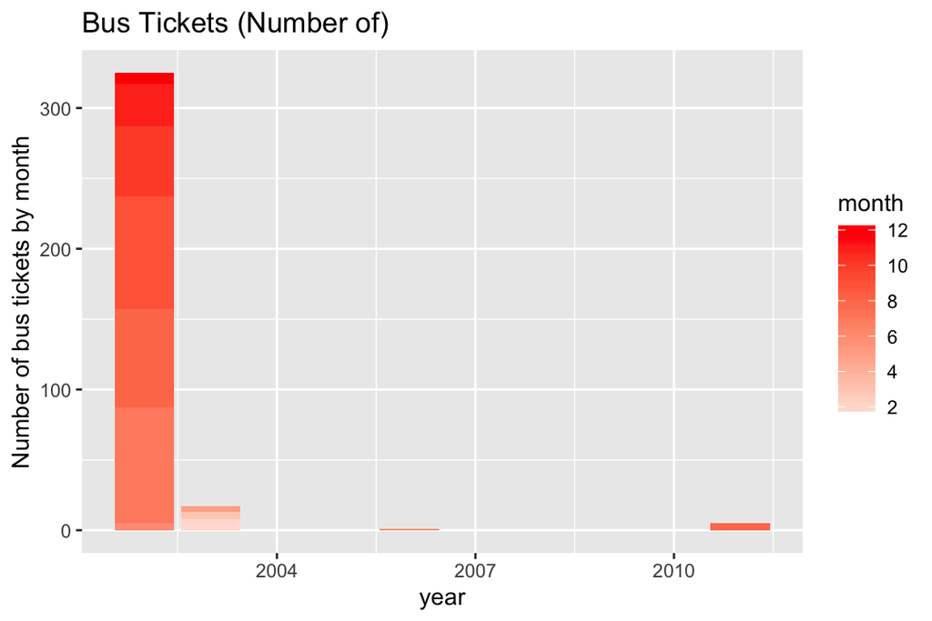

```r
#drop NA in Bus Tickets (Number of) and group it by year and month
df_bus <- df %>%
  filter(year>1996 & year<2019) %>%
  drop_na('Bus Tickets (Number of)') %>%
  filter('Bus Tickets (Number of)' > 0) %>%
  group_by(year, month) %>%
  summarise(count = n(),
            number_bus_tickets = sum(`Bus Tickets (Number of)`)
  )

ggplot(df_bus, aes(x=year, y=number_bus_tickets, fill = month)) +
  geom_col() +
  scale_fill_gradient2(low="blue", mid="white", high="red") +
  labs(title = 'Bus Tickets (Number of)',
       y = 'Number of bus tickets by month')
```

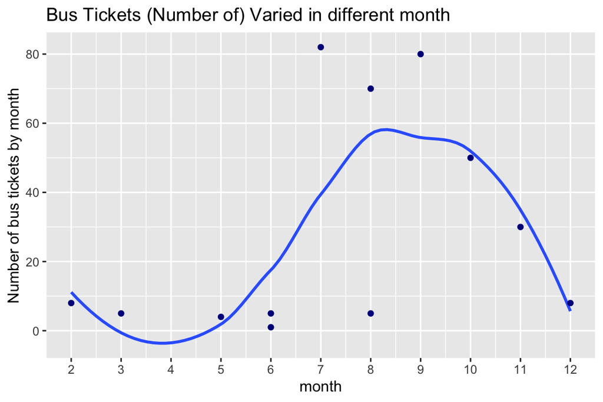

```r
ggplot(df_bus, aes(x=month, y=number_bus_tickets)) +
  geom_smooth(se = FALSE) +
  scale_x_continuous(breaks = seq(1:12)) +
  geom_point(color = 'darkblue') +
  labs(title = 'Bus Tickets (Number of) Varied in different month',
       y = 'Number of bus tickets by month')
```

To tidy the data, I removed all the NA and group it by year and month, and then calculated the sum of number of bus tickets provided each time. It is shown that the bus tickets support was mainly provided in 2002 and 2003, and only provided once in June 2006 and August 2011 respectively, which implies that the service discontinued. The support in bus tickets reached its peak around Aug.~Oct., maybe the clients prefer to use the bus pass to get to medical appointments or jobs during that time.

#### Diapers

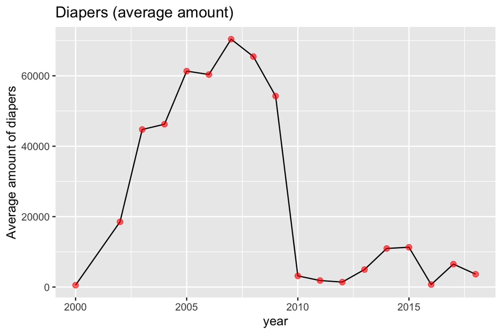

```r
df_diapers <- df %>%
  filter(year>1996 & year<2019 & Diapers<5000) %>%
  drop_na('Diapers') %>%
  group_by(year) %>%
  summarise(count = n(),
            diapers = sum(Diapers * 44)
  )

ggplot(df_diapers) +
  geom_line(mapping = aes(x = year, y = diapers)) +
  geom_point(mapping = aes(x = year, y = diapers),size = 2, alpha = 0.6, color='red') +
  labs(title = 'Diapers (average amount)',
       y = 'Average amount of diapers')
```

#### School Kits

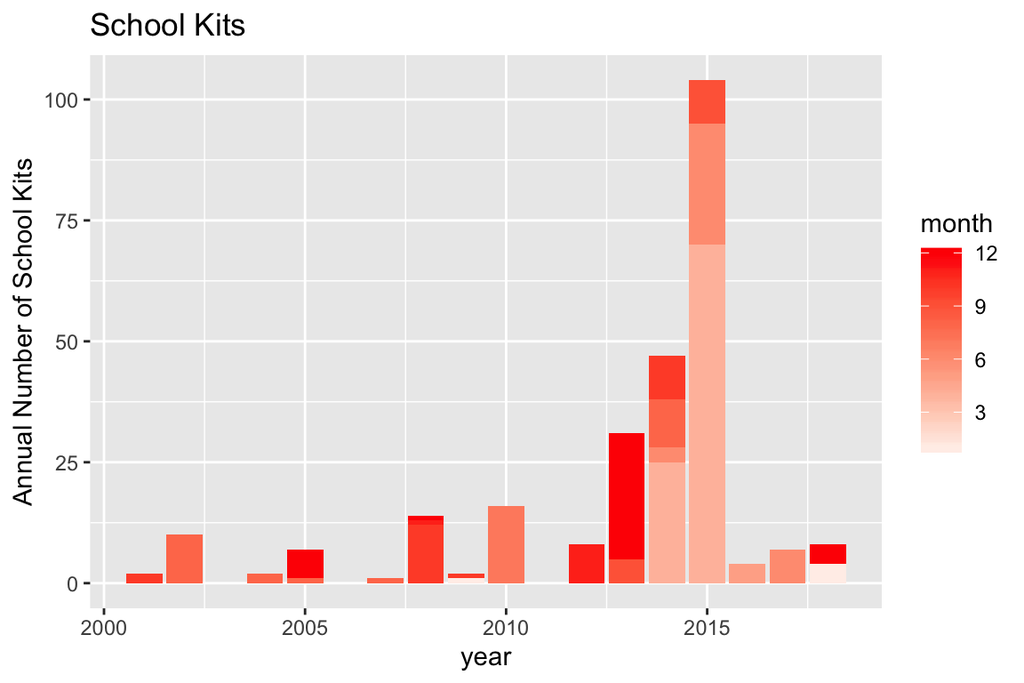

```r
df_schoolkits <- df %>%
  filter(year>1996 & year<2019) %>%
  drop_na('School Kits') %>%
  filter(`School Kits` > 0) %>%  #we treat 0 as NA
  group_by(year, month) %>%
  summarise(count = n(),
            school_kits = sum(`School Kits`)
  )

 ggplot(df_schoolkits, mapping = aes(x = year, y = school_kits, fill = month)) +
  geom_col() +
  scale_fill_gradient2(low="blue", mid="white", high="red") +
  labs(title = 'School Kits',
       y = 'Annual Number of School Kits')
```

```r
df_schoolkits.month <- df %>%
  filter(year>1996 & year<2019) %>%
  drop_na('School Kits') %>%
  filter(`School Kits` > 0) %>%  #we treat 0 as NA
  group_by(month) %>%
  summarise(count = n(),
            school_kits = sum(`School Kits`)
  ) %>%
  arrange(desc(school_kits))
df_schoolkits.month
```

```
## # A tibble: 10 x 3
##    month count school_kits
##    <dbl> <int>       <dbl>
##  1     4     6          95
##  2    12     5          37
##  3     6     3          35
##  4     8     9          24
##  5    10     4          24
##  6     7     1          16
##  7     9     2          14
##  8    11     2           9
##  9     1     2           5
## 10     5     1           4
```

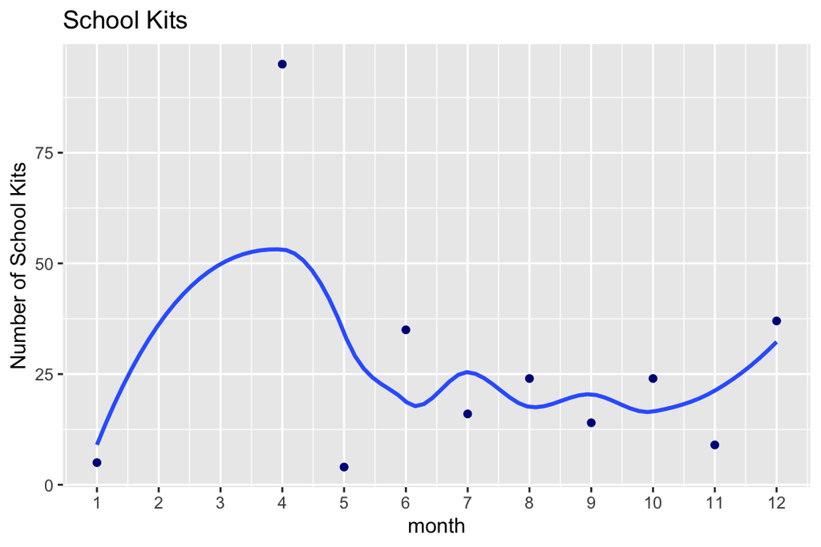

```r
ggplot(df_schoolkits.month, mapping = aes(x = month, y= school_kits)) +
  geom_smooth(se = FALSE) +
  scale_x_continuous(breaks = seq(1:12)) +
  geom_point(color = 'darkblue') +
  labs(title = 'School Kits',
       y = 'Number of School Kits')
```

#### Hgyiene Kits

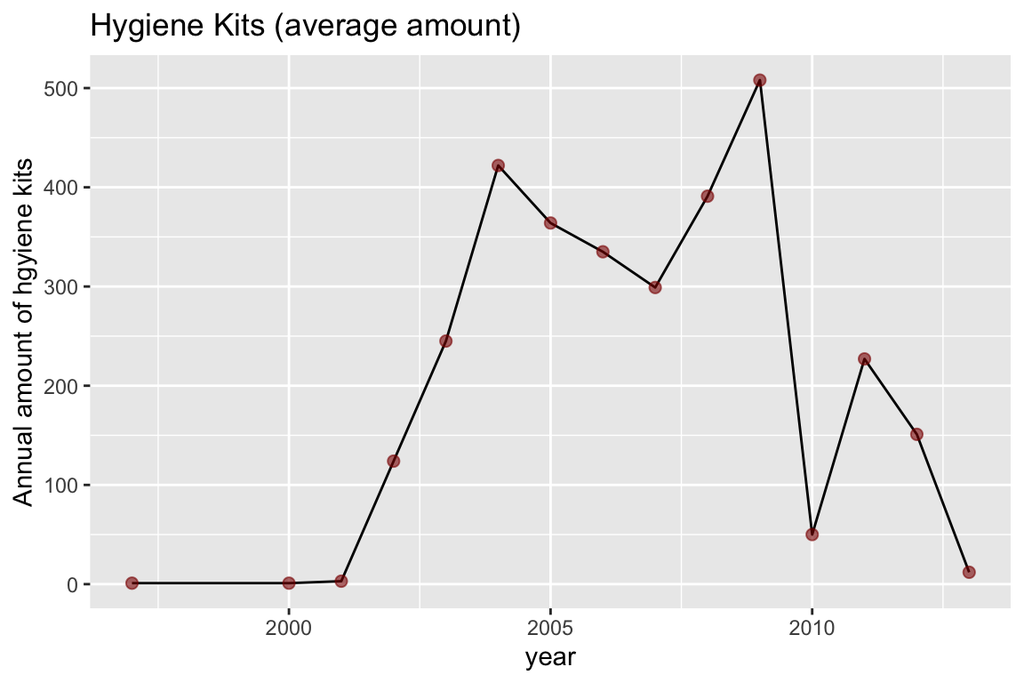

```r
df_hgkit <- df %>%
  filter(year>1996 & year<2019) %>%
  drop_na('Hygiene Kits') %>%
  group_by(year) %>%
  summarise(count = n(),
            hgkit = sum(`Hygiene Kits`)
  )

ggplot(df_hgkit) +
  geom_line(mapping = aes(x = year, y = hgkit)) +
  geom_point(mapping = aes(x = year, y = hgkit), size = 2, alpha = 0.6, color='darkred') +
  labs(title = 'Hygiene Kits (average amount)',
       y = 'Annual amount of hgyiene kits')
```

The service of providing hygiene kits was continued from 1997 to 2013. It began to increase from 2002 and decreased dramatically in 2010, and in 2013 the UMD only provided 12 hygiene kits, which is supposed to the reason they stopped this service then.

#### Financial Support

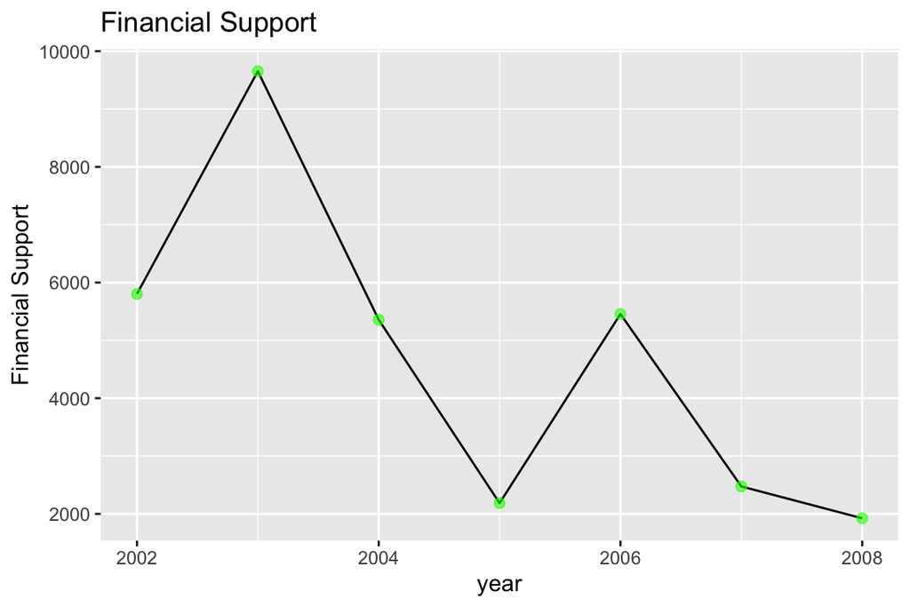

```r
df_finance <- df %>%
  filter(year>1996 & year<2019) %>%
  drop_na('Financial Support') %>%
  filter(`Financial Support` > 0) %>%
  group_by(year) %>%
  summarise(count = n(),
            finance = sum(`Financial Support`)
  )

ggplot(df_finance) +
  geom_line(mapping = aes(x = year, y = finance)) +
  geom_point(mapping = aes(x = year, y = finance),size = 2, alpha = 0.6, color='green') +
  labs(title = 'Financial Support',
       y = 'Financial Support')
```

The service of financial support was started in 2002 and discontinued in 2008. The money provided to the homeless keeps decreasing after 2006 and so dose the cases of this services.

## Food and Clothing

```r
df_main <- df %>%
  filter(year>1996 & year<2019) %>%
  drop_na(`Food Provided for`, `Food Pounds`, `Clothing Items`) %>%
  filter(`Food Provided for`>0) %>%
  select(year, month, day, `Food Provided for`, `Food Pounds`, `Clothing Items`) %>%
  mutate(ave_food_pounds = `Food Pounds`/`Food Provided for`) %>%
  filter(!is.na(ave_food_pounds))      #remove NA caused by 0 in `Food Provided for`
```

Filtering the valid data on `Food Provided for`, `Food Pounds` and `Clothing Items`, we can see that there are 44582 observations which are the most “complete” part of the study. In the following part of the project, I am going to draw analysis on food and clothing respectively.

#### Changes in Food Support over Time

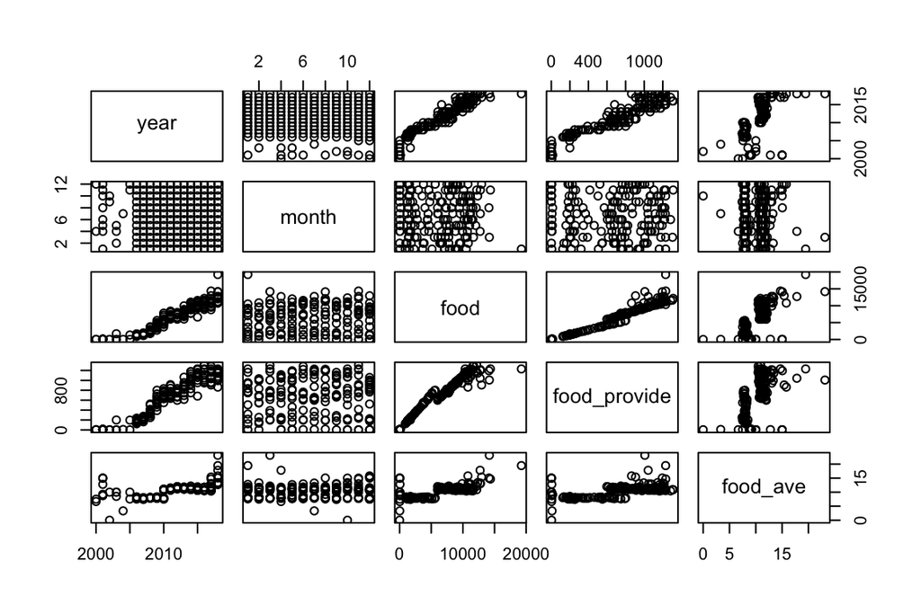

```r
df_food <- df_main %>%
  filter(year>1996 & year<2019) %>%
  group_by(year, month) %>%
  summarise(food = sum(`Food Pounds`),
            food_provide = sum(`Food Provided for`),
            food_ave = mean(ave_food_pounds))
pairs(df_food)
```

```r
cor(df_food[,1:4])
```

```
##                     year       month       food food_provide
## year          1.00000000 -0.04637601 0.94526546   0.94220822
## month        -0.04637601  1.00000000 0.04057823   0.04102325
## food          0.94526546  0.04057823 1.00000000   0.96747240
## food_provide  0.94220822  0.04102325 0.96747240   1.00000000
```

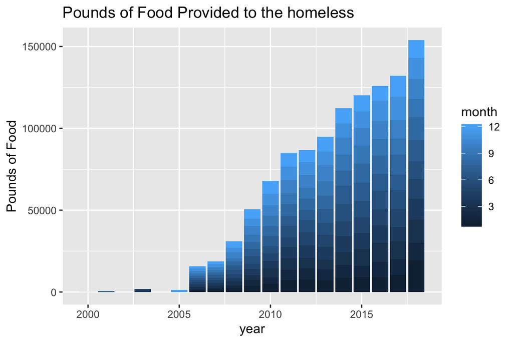

```r
ggplot(df_food, aes(x=year, y=food)) +
  geom_col(aes(fill=month)) +
  labs(title = 'Pounds of Food Provided to the homeless',
       y = 'Pounds of Food')
```

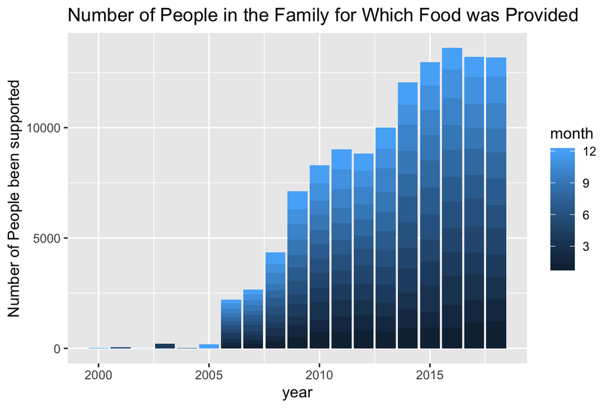

```r
ggplot(df_food, aes(x=year, y=food_provide)) +
  geom_col(aes(fill=month)) +
  labs(title = 'Number of People in the Family for Which Food was Provided',
       y = 'Number of People been supported')
```

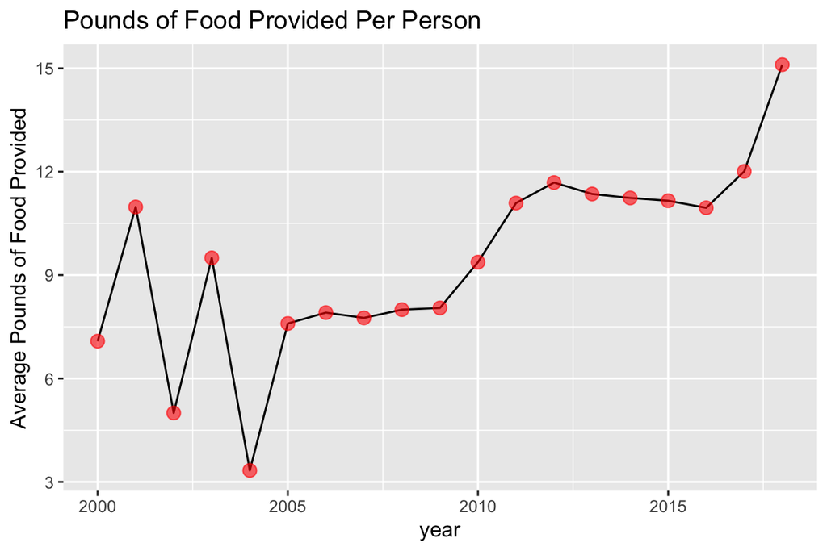

```r
df_food2 <- df_main %>%
  filter(year>1996 & year<2019) %>%
  group_by(year) %>%
  summarise(food_ave = mean(ave_food_pounds))

ggplot(df_food2, aes(x=year, y=food_ave)) +
  geom_line() +
  geom_point(size = 3, alpha = 0.6, color='red') +
  labs(title = 'Pounds of Food Provided Per Person',
       y = 'Average Pounds of Food Provided')
```

The Number of People Food Provided for and total food pounds positively correlated with year, and they also positively correlated with each other, which implies that the UMD is providing more and more food, and also to more and more clients over years. Whereas the food provided to each person did not keep increasing (keeps vibrating).

#### Changes in Clothing Support over Time

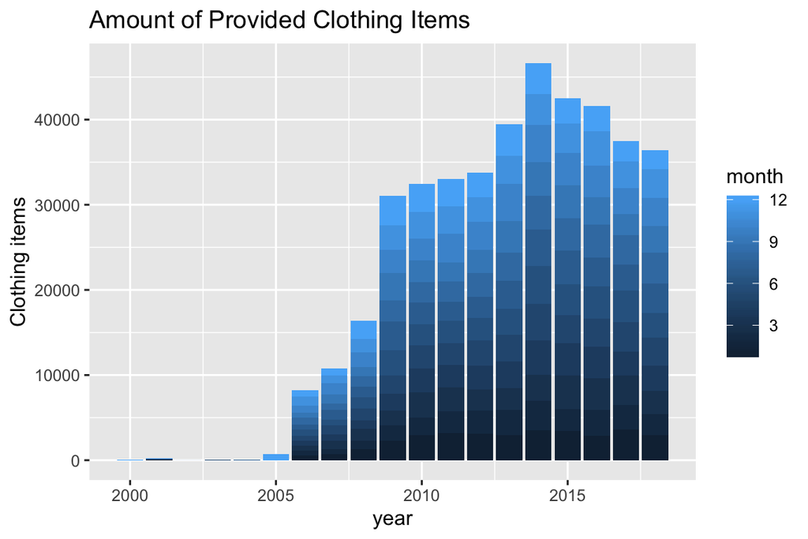

```r
df_cloth <- df_main %>%
  filter(year>1996 & year<2019) %>%
  group_by(year, month) %>%
  summarise(clothing = sum(`Clothing Items`))

ggplot(df_cloth, aes(x=year, y=clothing)) +
  geom_col(aes(fill=month)) +
  labs(title = 'Amount of Provided Clothing Items',
       y = 'Clothing items')
```

[figure not shown]

```r
ggplot(df_cloth, aes(x=month, y=clothing)) +
  geom_smooth() +
  scale_x_continuous(breaks = seq(1:12)) +
  geom_point(color = 'lightblue') +
  labs(title = 'Pounds of Food Provided Per Person',
       y = 'Average Pounds of Food Provided')
```

It is shown that the support in clothing increasing before 2015 and began to decrease slightly in recent years. However to my surprise, the provide of clothing seems not related to month (season).

## Analysis on Clients

In the part, I am going to predict the total demand and clients in 2019 with linear regression.

#### Prediction of 2019

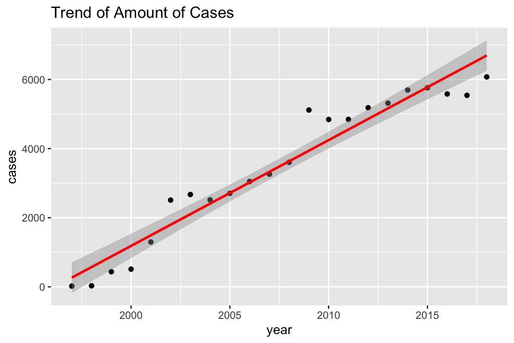

```r
df_client <- df %>%
  filter(year>1996 & year<2019) %>%
  group_by(year) %>%
  summarise(cases = n(),
            clients =length(unique(`Client File Number`)))

ggplot(df_client, aes(x = year, y = cases)) +
  geom_point() +
  stat_smooth(method = "lm", col = "red") +
  labs(title = 'Trend of Amount of Cases')
```

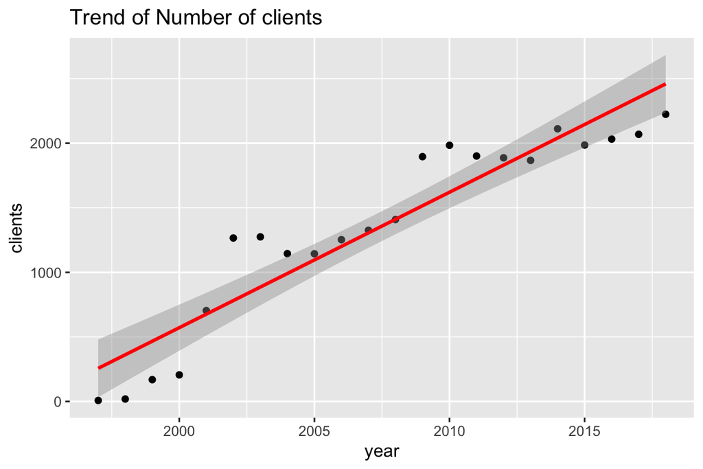

```r
ggplot(df_client, aes(x = year, y = clients)) +
  geom_point() +
  stat_smooth(method = "lm", col = "red") +
  labs(title = 'Trend of Number of clients')
```

```r
df_client.reduced <- df %>%
  filter(year>2010 & year<2019) %>%
  group_by(year) %>%
  summarise(cases = n(),
            clients =length(unique(`Client File Number`)))

lmod <- lm(cases ~ year, data = df_client.reduced) #predict the demand in 2019
predict_cases2019 <- lmod$coefficients %*% c(1,2019)

lmod2 <- lm(clients ~ year, data = df_client.reduced) #predict the clients in 2019
predict_clients2019 <- lmod2$coefficients %*% c(1,2019)
```

It is shown that the number of clients helped by UMD keeps increasing over years, so does the number of cases that UMD provided services. It seems very likely that the two variables increase linearly so then I have used linear regression to predict the demands in 2019.

According to the model, the number of cases of services will come to 6103, and the number of clients will increase to 2199.